# STAT 184 Final Project

Sai Dhanush D

```r
#loading all the required packages
library(DataComputing)
library(readr)
library(mosaic)
library(ggplot2)
library(party)
```

### Introduction

For my project, I will be using the “World Happiness Report” dataset. The World Happiness Report is a landmark survey of the state of global happiness. Since the publication of its first report, its survey methodology has remained the same: The reports are based on answers to a series of real life questions asked in the poll, varying across 6 main factors - Economy, Family support, life expectancy, freedom, generosity and absence of corruption. This is known as Cantril ladder where respondents are asked to think of a ladder, with the best possible life for them being a 10, and the worst possible life being a 0.

Since its inception, multiple nations, institutions and organizations have utilized, the World Happiness Report in a variety of ways, from economic research to the legislation of public policies.

### The Guiding Question

The World Happiness Report has answered many real-life questions, but at the same time, there are still many questions regarding the relationships between various factors and happiness that can be explored using the World Happiness Report. One such interesting question that caught my attention is the North-South divide. The North-South divide is a socio-economic divide which proves that countries in the Global North are economically wealthier than countries in the Global South. Since the cold-war era, for “more than a generation, this North-South divide was central to the explanation of world poverty”. Hence, we want to see if such also holds true for happiness.

In order to determine the North-South divide, I will be using the 2019 dataset as it is the latest dataset available to us. Similar to the datasets from previous years, the 2019 dataset has 156 unique countries listed with their overall rank and has all the values for the 6 main determining factors.

### Data Access

#### Importing Data

```r
#loading 2019 dataset from github repo
data2019<-readr::read_csv("https://raw.githubusercontent.com/said367/Final-Project/master/data2019.csv")
```

#### Inspecting Data

```r
#summary of the dataset
str(data2019)
```

```
Classes ‘spec_tbl_df’, ‘tbl_df’, ‘tbl’ and 'data.frame':    156 obs. of  9 variables:
 $ Rank         : num  1 2 3 4 5 6 7 8 9 10 ...
 $ Country      : chr  "Finland" "Denmark" "Norway" "Iceland" ...
 $ Score        : num  7.77 7.6 7.55 7.49 7.49 ...
 $ GDP          : num  1.34 1.38 1.49 1.38 1.4 ...
 $ SocialSupport: num  1.59 1.57 1.58 1.62 1.52 ...
 $ Health       : num  0.986 0.996 1.028 1.026 0.999 ...
 $ Freedom      : num  0.596 0.592 0.603 0.591 0.557 0.572 0.574 0.585 0.584 0.532 ...
 $ Generosity   : num  0.153 0.252 0.271 0.354 0.322 0.263 0.267 0.33 0.285 0.244 ...
 $ Corruption   : num  0.393 0.41 0.341 0.118 0.298 0.343 0.373 0.38 0.308 0.226 ...
 - attr(*, "spec")=
  .. cols(
  ..   Rank = col_double(),
  ..   Country = col_character(),
  ..   Score = col_double(),
  ..   GDP = col_double(),
  ..   SocialSupport = col_double(),
  ..   Health = col_double(),
  ..   Freedom = col_double(),
  ..   Generosity = col_double(),
  ..   Corruption = col_double()
  .. )
```

```r
summary(data2019)
```

```
      Rank          Country              Score            GDP         SocialSupport
 Min.   :  1.00   Length:156         Min.   :2.853   Min.   :0.0000   Min.   :0.000
 1st Qu.: 39.75   Class :character   1st Qu.:4.545   1st Qu.:0.6028   1st Qu.:1.056
 Median : 78.50   Mode  :character   Median :5.380   Median :0.9600   Median :1.272
 Mean   : 78.50                      Mean   :5.407   Mean   :0.9051   Mean   :1.209
 3rd Qu.:117.25                      3rd Qu.:6.184   3rd Qu.:1.2325   3rd Qu.:1.452
 Max.   :156.00                      Max.   :7.769   Max.   :1.6840   Max.   :1.624
     Health          Freedom         Generosity       Corruption
 Min.   :0.0000   Min.   :0.0000   Min.   :0.0000   Min.   :0.0000
 1st Qu.:0.5477   1st Qu.:0.3080   1st Qu.:0.1087   1st Qu.:0.0470
 Median :0.7890   Median :0.4170   Median :0.1775   Median :0.0855
 Mean   :0.7252   Mean   :0.3926   Mean   :0.1848   Mean   :0.1106
 3rd Qu.:0.8818   3rd Qu.:0.5072   3rd Qu.:0.2482   3rd Qu.:0.1412
 Max.   :1.1410   Max.   :0.6310   Max.   :0.5660   Max.   :0.4530
```

```r
data2019%>%sample_n(10)
```

| Rank | Country | Score | GDP | SocialSupport | Health | Freedom | Generosity | Corruption |
| --- | --- | --- | --- | --- | --- | --- | --- | --- |
| 24 | France | 6.592 | 1.324 | 1.472 | 1.045 | 0.436 | 0.111 | 0.183 |
| 26 | Chile | 6.444 | 1.159 | 1.369 | 0.920 | 0.357 | 0.187 | 0.056 |
| 91 | Lebanon | 5.197 | 0.987 | 1.224 | 0.815 | 0.216 | 0.166 | 0.027 |
| 9 | Canada | 7.278 | 1.365 | 1.505 | 1.039 | 0.584 | 0.285 | 0.308 |
| 21 | United Arab Emirates | 6.825 | 1.503 | 1.310 | 0.825 | 0.598 | 0.262 | 0.182 |
| 104 | Gabon | 4.799 | 1.057 | 1.183 | 0.571 | 0.295 | 0.043 | 0.055 |
| 93 | China | 5.191 | 1.029 | 1.125 | 0.893 | 0.521 | 0.058 | 0.100 |
| 105 | Laos | 4.796 | 0.764 | 1.030 | 0.551 | 0.547 | 0.266 | 0.164 |
| 4 | Iceland | 7.494 | 1.380 | 1.624 | 1.026 | 0.591 | 0.354 | 0.118 |
| 138 | Zambia | 4.107 | 0.578 | 1.058 | 0.426 | 0.431 | 0.247 | 0.087 |

We can see that our dataset doesn’t have the ‘Region’ attribute, which is the most important attribute in determining the North-South divide. So, in order to get the region attribute, we will have to compare our dataset to one of the past reports that have the region attribute and group the countries in our dataset into North and South based on their location.

```r
#loading the dataset from github repo
data2016<-readr::read_csv("https://raw.githubusercontent.com/said367/Final-Project/master/data2016.csv")
```

Now, let’s inspect the 2016 World Happiness report:

```r
#summary of the 2016 dataset
str(data2016)
```

```
Classes ‘spec_tbl_df’, ‘tbl_df’, ‘tbl’ and 'data.frame':    157 obs. of  13 variables:
 $ Country                      : chr  "Denmark" "Switzerland" "Iceland" "Norway" ...
 $ Region                       : chr  "Western Europe" "Western Europe" "Western Europe" "Western Europe" ...
 $ Rank                         : num  1 2 3 4 5 6 7 8 9 10 ...
 $ Score                        : num  7.53 7.51 7.5 7.5 7.41 ...
 $ Lower Confidence Interval    : num  7.46 7.43 7.33 7.42 7.35 ...
 $ Upper Confidence Interval    : num  7.59 7.59 7.67 7.58 7.47 ...
 $ GDP                          : num  1.44 1.53 1.43 1.58 1.41 ...
 $ Family                       : num  1.16 1.15 1.18 1.13 1.13 ...
 $ Health                       : num  0.795 0.863 0.867 0.796 0.811 ...
 $ Freedom                      : num  0.579 0.586 0.566 0.596 0.571 ...
 $ Trust (Government Corruption): num  0.445 0.412 0.15 0.358 0.41 ...
 $ Generosity                   : num  0.362 0.281 0.477 0.379 0.255 ...
 $ Dystopia Residual            : num  2.74 2.69 2.83 2.66 2.83 ...
 - attr(*, "spec")=
  .. cols(
  ..   Country = col_character(),
  ..   Region = col_character(),
  ..   Rank = col_double(),
  ..   Score = col_double(),
  ..   `Lower Confidence Interval` = col_double(),
  ..   `Upper Confidence Interval` = col_double(),
  ..   GDP = col_double(),
  ..   Family = col_double(),
  ..   Health = col_double(),
  ..   Freedom = col_double(),
  ..   `Trust (Government Corruption)` = col_double(),
  ..   Generosity = col_double(),
  ..   `Dystopia Residual` = col_double()
  .. )
```

```r
summary(data2016)
```

```
   Country             Region               Rank            Score
 Length:157         Length:157         Min.   :  1.00   Min.   :2.905
 Class :character   Class :character   1st Qu.: 40.00   1st Qu.:4.404
 Mode  :character   Mode  :character   Median : 79.00   Median :5.314
                                       Mean   : 78.98   Mean   :5.382
                                       3rd Qu.:118.00   3rd Qu.:6.269
                                       Max.   :157.00   Max.   :7.526
 Lower Confidence Interval Upper Confidence Interval      GDP             Family
 Min.   :2.732             Min.   :3.078             Min.   :0.0000   Min.   :0.0000
 1st Qu.:4.327             1st Qu.:4.465             1st Qu.:0.6702   1st Qu.:0.6418
 Median :5.237             Median :5.419             Median :1.0278   Median :0.8414
 Mean   :5.282             Mean   :5.482             Mean   :0.9539   Mean   :0.7936
 3rd Qu.:6.154             3rd Qu.:6.434             3rd Qu.:1.2796   3rd Qu.:1.0215
 Max.   :7.460             Max.   :7.669             Max.   :1.8243   Max.   :1.1833
     Health          Freedom       Trust (Government Corruption)   Generosity
 Min.   :0.0000   Min.   :0.0000   Min.   :0.00000               Min.   :0.0000
 1st Qu.:0.3829   1st Qu.:0.2575   1st Qu.:0.06126               1st Qu.:0.1546
 Median :0.5966   Median :0.3975   Median :0.10547               Median :0.2225
 Mean   :0.5576   Mean   :0.3710   Mean   :0.13762               Mean   :0.2426
 3rd Qu.:0.7299   3rd Qu.:0.4845   3rd Qu.:0.17554               3rd Qu.:0.3119
 Max.   :0.9528   Max.   :0.6085   Max.   :0.50521               Max.   :0.8197
 Dystopia Residual
 Min.   :0.8179
 1st Qu.:2.0317
 Median :2.2907
 Mean   :2.3258
 3rd Qu.:2.6646
 Max.   :3.8377
```

```r
data2016%>%sample_n(10)
```

| Country | Region | Rank | Score | Lower Confidence Interval | Upper Confidence Interval | GDP | Family | Health | Freedom | Trust (Government Corruption) | Generosity | Dystopia Residual |
| --- | --- | --- | --- | --- | --- | --- | --- | --- | --- | --- | --- | --- |
| Uzbekistan | Central and Eastern Europe | 49 | 5.987 | 5.896 | 6.078 | 0.73591 | 1.16810 | 0.50163 | 0.60848 | 0.28333 | 0.34326 | 2.34638 |
| Azerbaijan | Central and Eastern Europe | 81 | 5.291 | 5.226 | 5.356 | 1.12373 | 0.76042 | 0.54504 | 0.35327 | 0.17914 | 0.05640 | 2.27350 |
| Pakistan | Southern Asia | 92 | 5.132 | 5.038 | 5.226 | 0.68816 | 0.26135 | 0.40306 | 0.14622 | 0.13880 | 0.31185 | 3.18286 |
| Congo (Kinshasa) | Sub-Saharan Africa | 125 | 4.272 | 4.191 | 4.353 | 0.05661 | 0.80676 | 0.18800 | 0.15602 | 0.06075 | 0.25458 | 2.74924 |
| Suriname | Latin America and Caribbean | 40 | 6.269 | 6.073 | 6.465 | 1.09686 | 0.77866 | 0.50933 | 0.52234 | 0.12692 | 0.16665 | 3.06852 |
| China | Eastern Asia | 83 | 5.245 | 5.199 | 5.291 | 1.02780 | 0.79381 | 0.73561 | 0.44012 | 0.02745 | 0.04959 | 2.17087 |
| Rwanda | Sub-Saharan Africa | 152 | 3.515 | 3.444 | 3.586 | 0.32846 | 0.61586 | 0.31865 | 0.54320 | 0.50521 | 0.23552 | 0.96819 |
| Spain | Western Europe | 37 | 6.361 | 6.288 | 6.434 | 1.34253 | 1.12945 | 0.87896 | 0.37545 | 0.06137 | 0.17665 | 2.39663 |
| Japan | Eastern Asia | 53 | 5.921 | 5.850 | 5.992 | 1.38007 | 1.06054 | 0.91491 | 0.46761 | 0.18985 | 0.10224 | 1.80584 |
| Moldova | Central and Eastern Europe | 55 | 5.897 | 5.823 | 5.971 | 0.69177 | 0.83132 | 0.52309 | 0.25202 | 0.01903 | 0.19997 | 3.38007 |

### Data Wrangling

To group the countries into North and South, we need to divide them based on their region. To get the region attribute, we’ll have to join the two datasets by matching country names. We’ll only match those that are present in both the datasets.

```r
#adding the region attribute by joining the two datasets
WorldIndex<-data2019%>%left_join(data2016%>%select(Country,Region),by=c("Country"="Country"))
```

We now have to divide the countries into North or South based on their region.

```r
#Grouping the countries and regions that belong to North
p1<-WorldIndex%>%filter(grepl("Europe",Region))%>%mutate(Divide='North')
p2<-WorldIndex%>%filter(Region=='North America'|Region=='Australia and New Zealand'|Country=='Japan'|Country=='South Korea')%>%mutate(Divide='North')

#Grouping all the remaining countries and regions to South
p3<-WorldIndex%>%filter(Region!='Central and Eastern Europe',Region!='Western Europe',Region!='North America',Region!='Australia and New Zealand',Country!='Japan',Country!='South Korea')%>%mutate(Divide='South')

#joining both the North and South Region datasets
WorldIndex<-p1%>%full_join(p2)
WorldIndex<-WorldIndex%>%full_join(p3)
```

Now let us compare the average score for happiness in both North and South countries.

```r
#Avg score based on Divide
WorldIndex%>%group_by(Divide)%>%summarise(Average_Score=mean(Score))
```

| Divide | Average_Score |
| --- | --- |
| North | 6.168857 |
| South | 5.031284 |

Also, let us find the Top 10 Happiest and Saddest countries along with their Divide.

```r
#Top 10 happiest countries along with their Divide
WorldIndex%>%select(Country,Score,Divide)%>%arrange(desc(Score))%>%head(10)
```

| Country | Score | Divide |
| --- | --- | --- |
| Finland | 7.769 | North |
| Denmark | 7.600 | North |
| Norway | 7.554 | North |
| Iceland | 7.494 | North |
| Netherlands | 7.488 | North |
| Switzerland | 7.480 | North |
| Sweden | 7.343 | North |
| New Zealand | 7.307 | North |
| Canada | 7.278 | North |
| Austria | 7.246 | North |

```r
#Top 10 saddest countries along with their Divide
WorldIndex%>%select(Country,Score,Divide)%>%arrange(Score)%>%head(10)
```

| Country | Score | Divide |
| --- | --- | --- |
| South Sudan | 2.853 | South |
| Afghanistan | 3.203 | South |
| Tanzania | 3.231 | South |
| Rwanda | 3.334 | South |
| Yemen | 3.380 | South |
| Malawi | 3.410 | South |
| Syria | 3.462 | South |
| Botswana | 3.488 | South |
| Haiti | 3.597 | South |
| Zimbabwe | 3.663 | South |

### Data Visualization

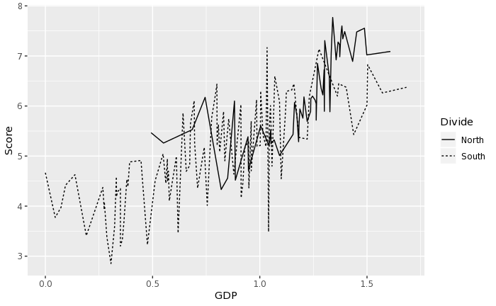

```r
WorldIndex%>%ggplot(aes(x=GDP,y=Score))+geom_line(aes(linetype=Divide))
```

We can also create a barplot that clearly shows the difference between countries in North and South region. As you can see, countries in North have high GDP and Happiness Score when compared to the countries in South.

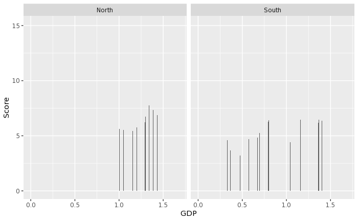

```r
WorldIndex%>%ggplot(aes(x=GDP,y=Score))+geom_col()+facet_grid(~Divide)
```

Additionally, we can create a decision tree to see how the factors such as Freedom and Social Support affect a country’s Happiness Score. It is clear from the decision tree below that a country with high Freedom and Social Support values have high Happiness scores than compared to those with low Freedom and Social Support scores.

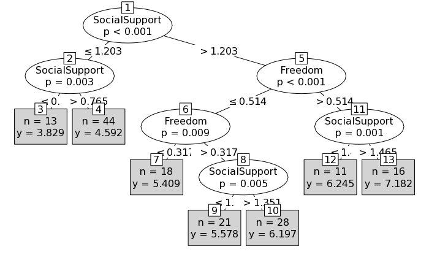

```r
#Decision tree to see if there's a relation between Happiness score, freedom and Social support
WorldIndex<-WorldIndex%>%na.omit()
dt1<-party::ctree(Score~Freedom+SocialSupport,data = WorldIndex)
plot(dt1,type='simple')
```